# Part II, INTRODUCTION TO MACHINE LEARNING

Markus Loecher, Berlin School of Economics and Law

# 1 Intro Machine Learning

## 1.1 Nonlinear Models

### 1.1.1 Polynomials

```r
Advertising = Advertising[order(Advertising$TV),]
fit1= lm(Sales ~ TV, data = Advertising)
fit2= lm(Sales ~ TV + poly(TV,2), data = Advertising)

summary(fit1)$adj.r.sq
```

```
## [1] 0.6099148
```

```r
fit2= lm(Sales ~ TV + poly(TV,25), data = Advertising)
plot(Sales ~ TV, data = Advertising)
#abline(fit1, col=2, lwd=2)
lines(Advertising$TV, fit2$fitted.values, col = "green", lwd=2)
summary(fit2)$adj.r.sq
```

```
## [1] 0.5983719
```

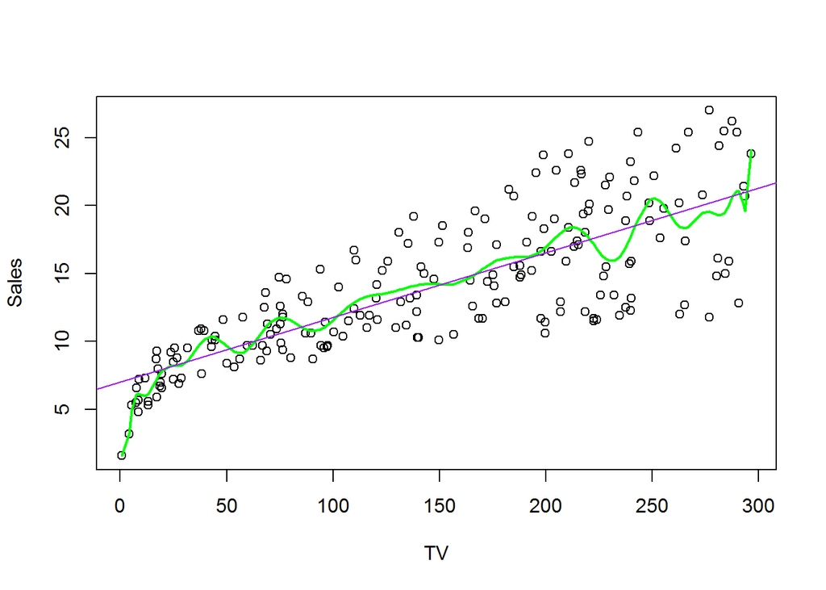

```r
abline(fit1,col="blue")
abline(fit2,col="purple")
```

### 1.1.2 model comparison

See page 130 in the ISL book.

The anova() function performs a hypothesis test comparing the two models. The null hypothesis is that the two models fit the data equally well, and the alternative hypothesis is that the full model is superior.

```r
anova(fit1,fit2)
```

```
## Analysis of Variance Table
##
## Model 1: Sales ~ TV
## Model 2: Sales ~ TV + poly(TV, 25)
##   Res.Df    RSS Df Sum of Sq      F Pr(>F)
## 1    198 2102.5
## 2    174 1902.3 24    200.18 0.7629 0.7788
```

### 1.1.3 GAMs

The s() function, which is part of the gam library, is used to indicate that we would like to use a smoothing spline. We specify that the function of year should have 4 degrees of freedom, and that the function of age will have 5 degrees of freedom. Since education is qualitative, we leave it as is, and it is converted into four dummy variables.We use the gam() function in gam() order to fit a GAM using these components. All of the terms are fit simultaneously, taking each other into account to explain the response.

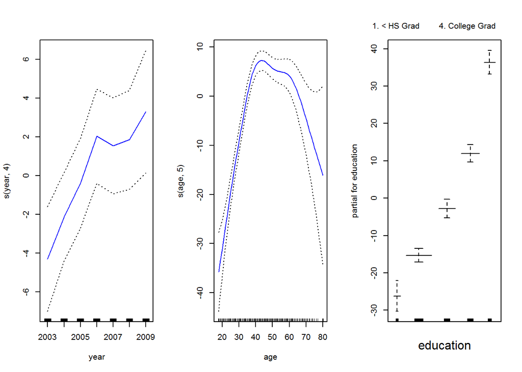

```r
library (gam)
gam.m3=gam(wage ~ s(year ,4)+s(age ,5)+education ,data=Wage)

par(mfrow =c(1,3))
plot(gam.m3, se=TRUE ,col ="blue ")
```

In these plots, the function of year looks rather linear. We can perform a series of ANOVA tests in order to determine which of these three models is best: a GAM that excludes year (M1), a GAM that uses a linear function of year (M2), or a GAM that uses a spline function of year (M3).

```r
gam.m1=gam(wage ~ s(age ,5) +education ,data=Wage)
gam.m2=gam(wage ~ year+s(age ,5)+education ,data=Wage)
anova(gam.m1 ,gam.m2 ,gam.m3,test="F")
```

```
## Analysis of Deviance Table
##
## Model 1: wage ~ s(age, 5) + education
## Model 2: wage ~ year + s(age, 5) + education
## Model 3: wage ~ s(year, 4) + s(age, 5) + education
##   Resid. Df Resid. Dev Df Deviance       F    Pr(>F)
## 1      2990    3711731
## 2      2989    3693842  1  17889.2 14.4771 0.0001447 ***
## 3      2986    3689770  3   4071.1  1.0982 0.3485661
## ---
## Signif. codes:  0 '***' 0.001 '**' 0.01 '*' 0.05 '.' 0.1 ' ' 1
```

We find that there is compelling evidence that a GAM with a linear function of year is better than a GAM that does not include year at all (p-value=0.00014). However, there is no evidence that a non-linear function of year is needed (p-value=0.349). In other words, based on the results of this ANOVA, M2 is preferred.

### 1.1.4 mgcv library

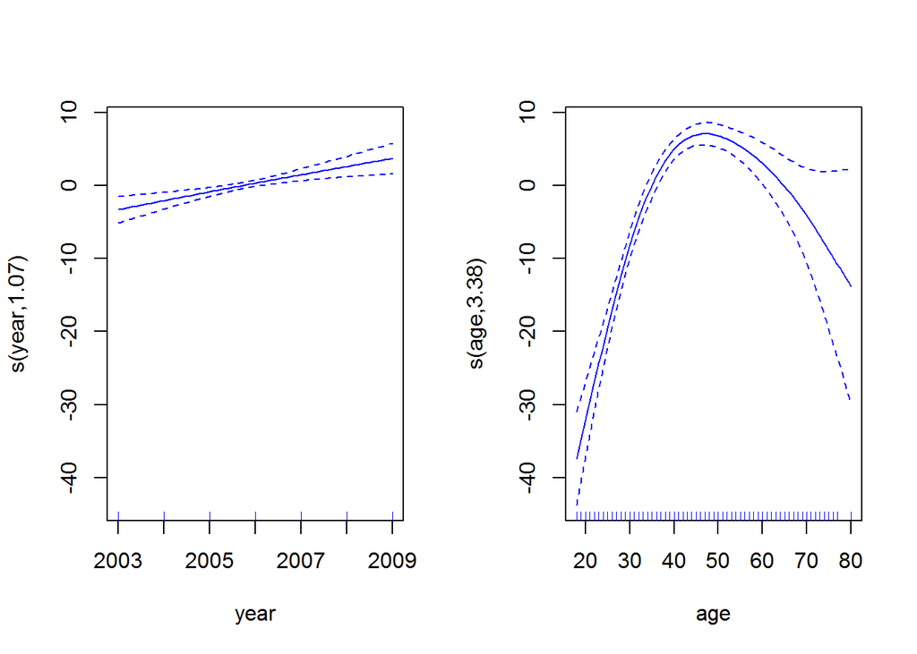

```r
#detach("package:gam", unload=TRUE)
library(mgcv)

gam.m4= mgcv::gam(wage ~ s(year ,k=4)+s(age ,k=5)+education ,data=Wage)

par(mfrow =c(1,2))
plot(gam.m4, se=TRUE ,col ="blue ")
```

### 1.1.5 Locations of knots

For penalized regression spline, the exact locations are not important, as long as:

- k is adequately big;
- the spread of knots has good, reasonable coverage.

By default:

- natural cubic regression spline bs = ‘cr’ places knots by quantile;
- B-splines family (bs = ‘bs’, bs = ‘ps’, bs = ‘ad’) place knots evenly.

Compare the following:

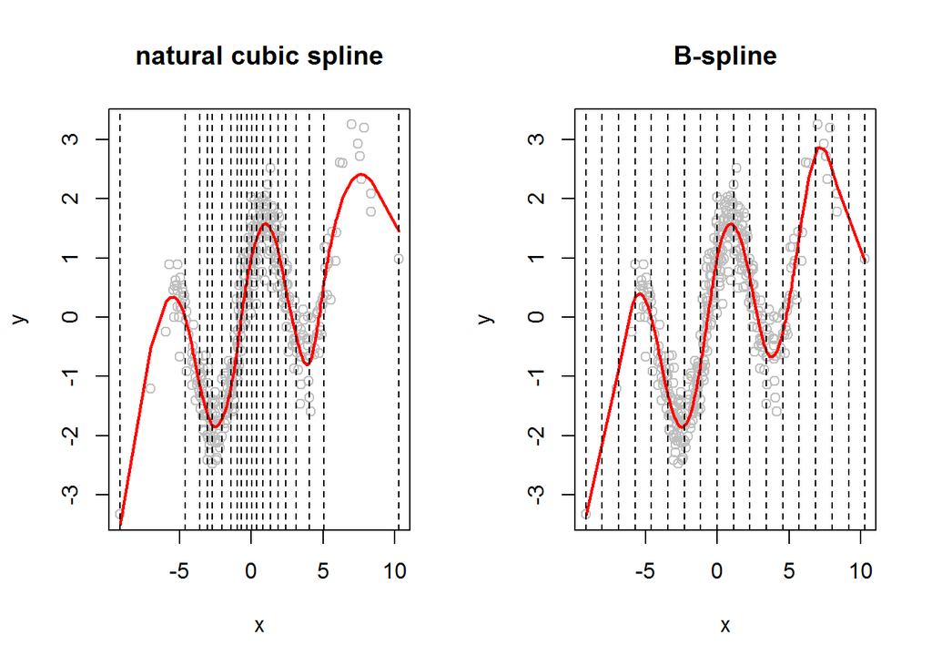

```r
library(mgcv)

## toy data
set.seed(0); x <- sort(rnorm(400, 0, pi))  ## note, my x are not uniformly sampled
set.seed(1); e <- rnorm(400, 0, 0.4)
y0 <- sin(x) + 0.2 * x + cos(abs(x))
y <- y0 + e

## fitting natural cubic spline
cr_fit <- gam(y ~ s(x, bs = 'cr', k = 20))
cr_knots <- cr_fit$smooth[[1]]$xp  ## extract knots locations

## fitting B-spline
bs_fit <- gam(y ~ s(x, bs = 'bs', k = 20))
bs_knots <- bs_fit$smooth[[1]]$knots  ## extract knots locations

## summary plot
par(mfrow = c(1,2))
plot(x, y, col= "grey", main = "natural cubic spline");
lines(x, cr_fit$linear.predictors, col = 2, lwd = 2)
abline(v = cr_knots, lty = 2)
plot(x, y, col= "grey", main = "B-spline");
lines(x, bs_fit$linear.predictors, col = 2, lwd = 2)
abline(v = bs_knots, lty = 2)
```

### 1.1.6 Setting your own knots locations:

You can also provide your customized knots locations via the knots argument of gam() (yes, knots are not fed to s(), but to gam()). For example, you can do evenly spaced knots for cr:

```r
xlim <- range(x)  ## get range of x
myfit <- gam(y ~ s(x, bs = 'cr', k =20),
         knots = list(x = seq(xlim[1], xlim[2], length = 20)))
```

Now you can see that:

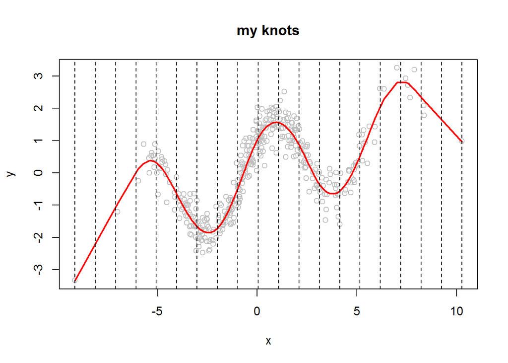

```r
my_knots <- myfit$smooth[[1]]$xp
plot(x, y, col= "grey", main = "my knots");
lines(x, myfit$linear.predictors, col = 2, lwd = 2)
abline(v = my_knots, lty = 2)
```

### 1.1.7 nearest neighbor models

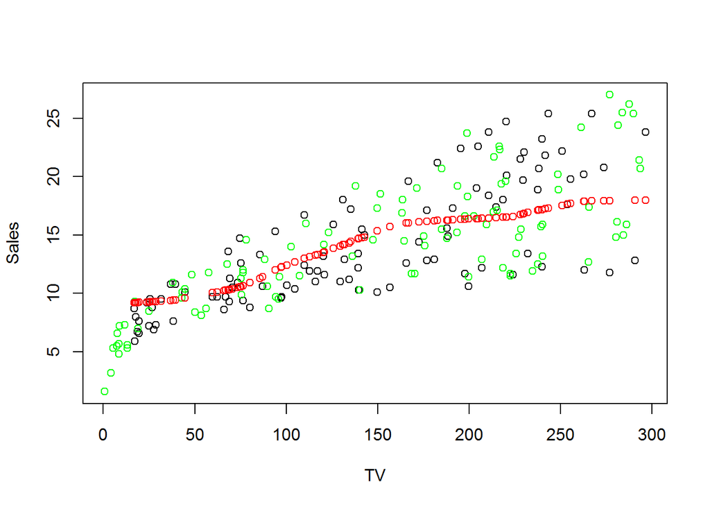

```r
library(kknn)

#fitNN = kknn(Sales ~ TV, distance=10, train = Advertising)

train=sample(nrow(Advertising),100)
Ad.kknn = kknn(Sales ~ TV, Advertising[train,],Advertising[-train,],distance=1, k = 50)
fit4 = fitted(Ad.kknn)
plot(Sales ~ TV, data = Advertising)
points(Sales ~ TV, data = Advertising[train,],col="green")
points(Advertising[-train,"TV"],fit4,col="red")
```

What is the R squared equivalent for nearest neighbors?

```r
cor(Advertising[-train,"Sales"],fit4)^2
```

```
## [1] 0.5627878
```

## 1.2 Classification

Let us make a binary feature in the Advertising data:

```r
Advertising$HighSales = Advertising$Sales > median(Advertising$Sales)
Advertising$HighSales = factor(Advertising$HighSales)
Ad.kknn.Class = kknn(HighSales ~ TV, Advertising[train,],Advertising[-train,],distance=1, k = 5)
PredClass = fitted(Ad.kknn.Class)
```

For classification NN is a majority vote !

### 1.2.1 Quality measure for Classification

Confusion Matrix !!!

```r
PredClass = fitted(Ad.kknn.Class)
ActualClass = Advertising[-train,]$HighSales
#compare PredClass with ActualClass
ConfMat = table(PredClass,ActualClass)
colnames(ConfMat) = c("Low", "High")
rownames(ConfMat) = c("Low", "High")
ConfMat
```

```
##          ActualClass
## PredClass Low High
##      Low   33    6
##      High  23   38
```

What is the model flexibility for nearest neighbors ?

Disadvantages

1. Absolutely no variable selection/weighting
2. Difficult to interpret or take stories away
3. Curse of dimensionality

## 1.3 Test Error Estimation

### 1.3.1 Overfitting

base model:

```r
library(MASS)
data("Boston")
train = Boston[1:250,]
fit1 = lm(medv ~ rm + crim + rad + dis, data = train)
summary(fit1)$r.square
```

```
## [1] 0.7710289
```

```r
fit2 = lm(medv ~ . , data = train)
summary(fit2)$r.squared
```

```
## [1] 0.8557424
```

```r
summary(fit1)$adj.r.squared
```

```
## [1] 0.7672906
```

```r
summary(fit2)$adj.r.squared
```

```
## [1] 0.8477961
```

### 1.3.2 train/test

Can we divide our data into train and test ??

```r
test = Boston[-(1:250),]

preds1 = predict(fit1, test)
preds2 = predict(fit2, test)
```

prediction error usually measured as rmse

```r
(rmse1=sqrt(mean((preds1-test$medv)^2)))
```

```
## [1] 8.211797
```

```r
(rmse2=sqrt(mean((preds2-test$medv)^2)))
```

```
## [1] 17.4388
```

```r
cor(preds1, test$medv)^2
```

```
## [1] 0.3727638
```

```r
cor(preds2, test$medv)^2
```

```
## [1] 0.004468268
```

There is a general attempt to be parsimonious in modeling

#### 1.3.2.1 Occam’s razor: the smallest model possible is the best

```r
TestError = function(
  x=Advertising,
  k=2
){
  set.seed(1234)
  #split into train and test
  N = nrow(x)
  trainRows = sample(N,round(0.5*N))# we choose no replacement. With replacement is called bootstrap
  xTrain = x[trainRows,]
  xTest = x[-trainRows,]
  #fit on train
  fit = lm(Sales ~ poly(TV,k), data = xTrain)
  #predict on test
  preds = predict(fit, xTest)
  #compute SS
  TrainError = sum((fit$fitted.values-xTrain$Sales)^2)
  cat("train error:", TrainError, "\n")
  PredError = sum((preds-xTest$Sales)^2)
  return(PredError)
}

TestError(Advertising, 2)
```

```
## train error: 998.6121
```

```
## [1] 1076.651
```

```r
TestError(Advertising, 20)
```

```
## train error: 882.3917
```

```
## [1] 2436.315
```

## 1.4 Cross validation

```r
myCV = function(
  x=Advertising,
  form = as.formula(Sales ~ TV + Newspaper + Newspaper:TV),
  kfold = 10,
  verbose = 0
){
  set.seed(123)
  #split into train and test
  N = nrow(x)
  PredError=vector()

  trainRows = rep_len(1:kfold, N)
  for(k in 1:kfold)
  {
    fold = which(trainRows == k)
    xTrain <- x[-fold,]
    xTest <- x[fold,]

    #fit on train
    fit = lm(form, data = xTrain)
    #predict on test
    preds = predict(fit, xTest)
    #compute SS
    TrainError = mean((fit$fitted.values-xTrain$Sales)^2)
    PredError[k] = mean((preds-xTest$Sales)^2)
    if (verbose) cat("pred error:", round(PredError[k],2), "\n")
  }
  #how many elements in PredError ?
  return(mean(PredError))
}

myCV()
```

```
## [1] 9.763224
```

#### 1.4.0.1 knn CV

```r
CVknn = function(
  x=Advertising,
  kNN = 10, # number of nearets neighbors
  form = as.formula(Sales ~ TV + Newspaper),
  y = "Sales",
  kfold = 10,
  verbose = 0
){
  library(kknn)
  set.seed(123)
  x = x[sample(1:nrow(x)),]
  #split into train and test
  N = nrow(x)
  PredError=vector()

  trainRows = rep_len(1:kfold, N)
  for(k in 1:kfold)
  {
    fold = which(trainRows == k)
    xTrain <- x[-fold,]
    xTest <- x[fold,]

    #fit on train
    fit = kknn(form, xTrain, xTest,distance=1, k = kNN)
    #predict on test
    preds = fitted(fit)
    #compute SS
    #TrainError = mean((fit$fitted.values-xTrain$Sales)^2)
    PredError[k] = mean((preds-xTest[,y])^2)
    if (verbose) cat("pred error:", round(PredError[k],2), "\n")
  }
  #how many elements in PredError ?
  return(mean(PredError))
}
CVknn(kNN=10)
```

```
## [1] 10.14359
```

```r
CVknn(kNN=50)
```

```
## [1] 10.97175
```

```r
CVknn(kNN=100)
```

```
## [1] 12.47764
```